# A3: Incarceration

Ahmed Ghaddah

02/17/20201

### Introduction + Summary Information

In this report, I will be analyzing Vera’s data to understand the details on the sources provided by their Incarceration Trends dataset.

Vera decided to to merged both their data with the data created by the Bureau of Justice Statistics– the original jails dataset. Vera did this in order to “first-of-a-kind national dataset that can examine both jail and prison incarceration at the county level”.

Vera developed four other publications about jail system regarding growth of prison in small cities, lack of data for covering race, rise of woman in prisons. The Article, [*Divided Justice: Trends in Black and White Incarceration 1990-2013*](https://www.vera.org/publications/divided-justice-black-white-jail-incarceration), caught my eye because they discussed that the BJS data was not compeletly accurate because they only caculate ethinicity during certain dates meaning they’d be missing a fare amount of data. Yet with that missing data regarding ethnicity, a black person is still *3.6x* more likely to be incarcerated in local jail *NATIONALLY* than white people. On top of that, after reading another article by Vera they stated that amongst large cities their amount of incarcerations has decreased, but small cities are still increasing.

This lead my interest to look into variables regarding the black population in comparison to other ethicities Specifically, I am very interested in finding the correlation of black people and comparing to other variables. I am not very educated in the incarceration of my own people, African American, I strive to use this assignment to gain my knowledge and back up what I heard, statistically, on the issue of exceptionally large black incarceration level.

I chose my exploratory questions to better grasp the black incarcerations in other locations. I have read about issues of black incarceration in Washington, California, New York, and Maryland. However, away from that my knowledge in other states was very low. So, I used the DPLYR function to further find locations surrounding the issue at hand. Out of all my exploration question I was insanely surprised that Dagget County, Utah has the highest ratio of jailed black people compared to those that reside in that county. Additionally, Dagget County, Utah had the highest jail population rate in all the counties in the US. I never heard of Dagget County, Utah and let alone expected that they had a rapidly rising issue in black incarceration levels.

#### The variables I will be looking at:

- black_jail_pop
- black_jail_pop_rate
- black_prison_rate
- black_pop_15to64
- county_name & state (location)
- Other ethinicity jail_pop, jail_pop_rate, jail_prison_rate, and pop_15to63

### Exploritory Problems using DPLYR functions

What counties have the highest black jail population?

Jefferson County, AL, Maricopa County, AZ, Pulaski County, AR, District of Columbia, DC, Broward County, FL, Marion County, IN, Androscoggin County, ME, Baltimore city, MD, Suffolk County, MA, Clark County, NV, Strafford County, NH, Essex County, NJ, New York County, NY, Oklahoma County, OK, Charleston County, SC, Shelby County, TN, King County, WA, Milwaukee County, WI, Campbell County, WY

According to the most recent date, what county has the highest black population?

New York County, NY

What county has the highest ratio of black people jailed compared to all black people in their county?

Daggett County, UT

What county had the highest difference between black people jailed and white people in jailed. In the most recent year?

Cook County, IL

Find the top 5 locations with highest black jail population rate

Daggett County, UT, King County, TX, Caldwell County, MO, St. Clair County, MO, Throckmorton County, TX

## Trends over Time Chart

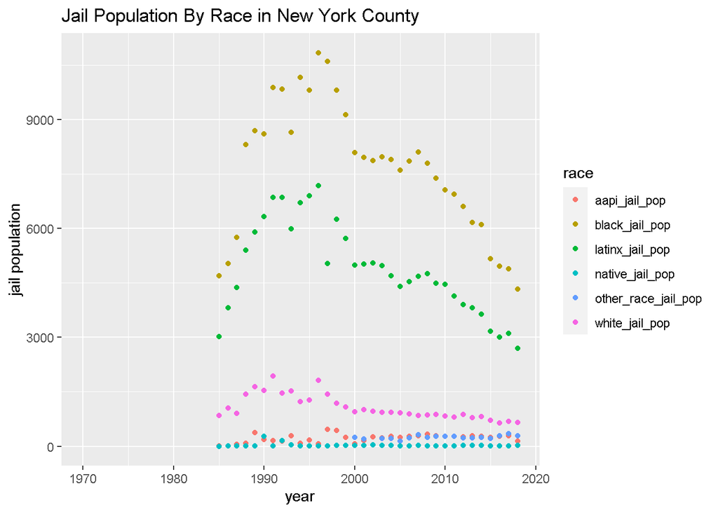

This graph illustrates the growth of the jail population between different ethnic groups in New York County. The summary stats are the jail population of different ethnic groups over time in New York City. From the graph we can see that black and latinx have always been the top two races with highest jail population. We can also observe that there is not a single moment in which the black jail population isn’t the highest. Each dot pin point illustrates the jail population according to a certain year. Each dot is assigned a color to indicate the race the dot correlates with. I choose this graph because I wanted to see the growth of the black jail population against other ethnic groups in New York County. I chose New York County because many African Americans reside there, and I wanted to find out, since it has one of the highest populations of African Americans, what would the jail incarceration levels look like? Although, New York County is the most populated county with black people, Black people only make up approximately 12.5% of New York County population. Yet it is shocking that they are significantly higher in the level of jail incarcerations than their fellow racial groups. This could be because the racial bias and brutality that the NYPD system has had, which has, just recently, been focused on. Sadly, before this year it has been constantly looked over.

## Variable comparison chart

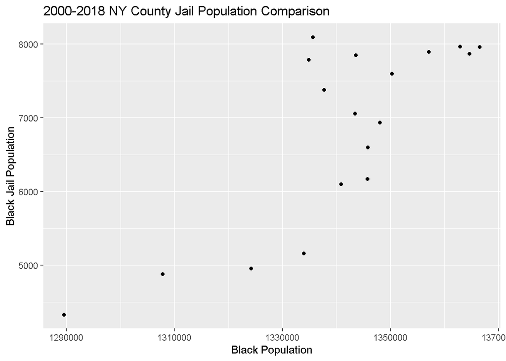

This graph illustrates the comparison between black population to the Black Jail Population in New York County . The summary statistics I used are the black_pop and black_jail_pop filtered to only focus on New York County. I used the time frame 2000-2018 to keep observation to be recent and have the graph be easier to read. Each dot pin points the black population compared to the black population. I chose these variables in my comparison chart to see if their were a correlation in black jail population rising, if the black population would rise. From the graph I found that, in the beginning, as the population was bigger so did the population of blacks in jail. However, at a certain point (between 1330000 - 1350000) that was no longer true. At that certain point, their was not much change in population, yet the growth of the black jailed population was still growing rapidly. I assumed that one of the factors of the black jail population growing would be because of that the bigger the black population. However, It looks to be their isn’t a strong correlation to that statement.

## Heat Map

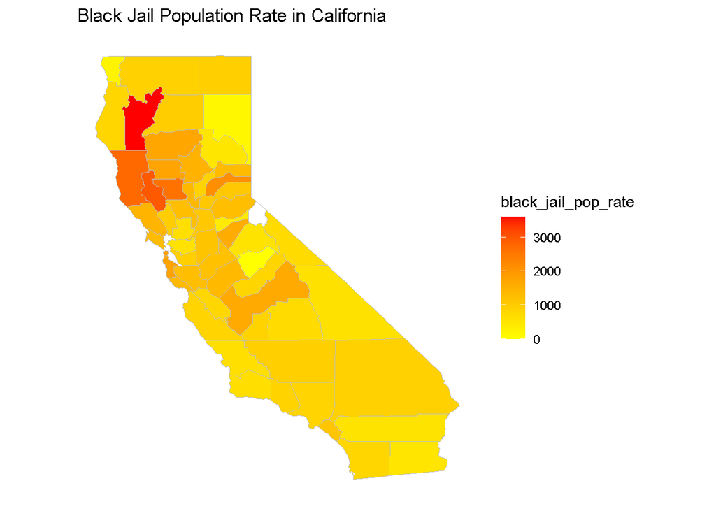